# Reproducible Research: Peer Assessment 1

## Loading and preprocessing the data

1. Load the data

```r
ac <- read.csv("./activity/activity.csv", header = TRUE)
```

2. Remove the NA values

```r
ac1 <- na.omit(ac)
```

## What is mean total number of steps taken per day?

1. Calculate the total number of steps taken per day

```r
(ac2 <- aggregate(data.frame(tsteps =ac1$steps), by =list(day = ac1$date), sum))
```

```
##           day tsteps
## 1  2012-10-02    126
## 2  2012-10-03  11352
## 3  2012-10-04  12116
## 4  2012-10-05  13294
## 5  2012-10-06  15420
## 6  2012-10-07  11015
## 7  2012-10-09  12811
## 8  2012-10-10   9900
## 9  2012-10-11  10304
## 10 2012-10-12  17382
## 11 2012-10-13  12426
## 12 2012-10-14  15098
## 13 2012-10-15  10139
## 14 2012-10-16  15084
```

[output cut: 39 more lines]

2. Make a histogram of the total number of steps taken each day

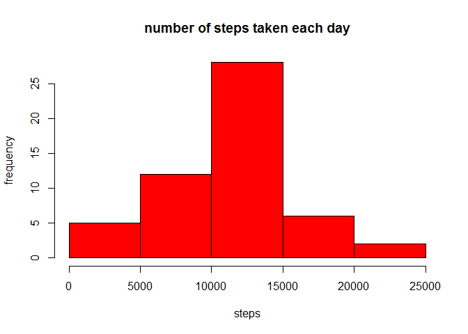

```r
hist(ac2$tsteps, main="number of steps taken each day",
     xlab="steps", ylab= "frequency", col="red")
```

3. Calculate and report the mean and median of the total number of steps taken per day

```r
aggregate(data.frame(mnsteps =ac1$steps), by =list(day = ac1$date), mean)
```

```
##           day    mnsteps
## 1  2012-10-02  0.4375000
## 2  2012-10-03 39.4166667
## 3  2012-10-04 42.0694444
## 4  2012-10-05 46.1597222
## 5  2012-10-06 53.5416667
## 6  2012-10-07 38.2465278
## 7  2012-10-09 44.4826389
## 8  2012-10-10 34.3750000
## 9  2012-10-11 35.7777778
## 10 2012-10-12 60.3541667
## 11 2012-10-13 43.1458333
## 12 2012-10-14 52.4236111
## 13 2012-10-15 35.2048611
## 14 2012-10-16 52.3750000
```

[output cut: 39 more lines]

```r
aggregate(data.frame(mdsteps =ac1$steps), by =list(day = ac1$date), median)
```

```
##           day mdsteps
## 1  2012-10-02       0
## 2  2012-10-03       0
## 3  2012-10-04       0
## 4  2012-10-05       0
## 5  2012-10-06       0
## 6  2012-10-07       0
## 7  2012-10-09       0
## 8  2012-10-10       0
## 9  2012-10-11       0
## 10 2012-10-12       0
## 11 2012-10-13       0
## 12 2012-10-14       0
## 13 2012-10-15       0
## 14 2012-10-16       0
```

[output cut: 39 more lines]

## What is the average daily activity pattern?

1. Make a time series plot of the 5-minute interval (x-axis) and the average number of steps taken, averaged across all days (y-axis)

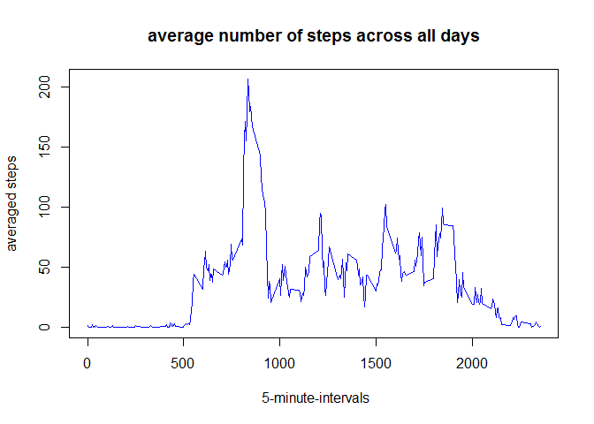

```r
ac3 <- aggregate(data.frame(steps =ac1$steps), by =list(int = ac1$interval), mean)
with(ac3, plot(int,steps,type="l",col="blue",main="average number of steps across all days",
               xlab=" 5-minute-intervals", ylab="averaged steps"))
```

2. Which 5-minute interval, on average across all the days in the dataset, contains the maximum number of steps?

```r
ac3[which(ac3$steps==max(ac3$steps)),1]
```

```
## [1] 835
```

## Imputing missing values

1. Calculate and report the total number of missing values in the dataset

```r
ac4 <- ac[is.na(ac),]
nrow(ac4)
```

```
## [1] 2304
```

2. Devise a strategy for filling in all of the missing values in the dataset.
- we will use the mean of the 5-minute interval.
3. Create a new dataset that is equal to the original dataset but with the missing data filled in

```r
ac4$steps <- NULL
ac4 <- merge(ac4,ac3, by.x = c("interval"), by.y = c("int"))
ac4$int <- NULL
ac4$day <- NULL
ac5 <- rbind(ac4,ac1)
```

4. Make a histogram of the total number of steps taken each day

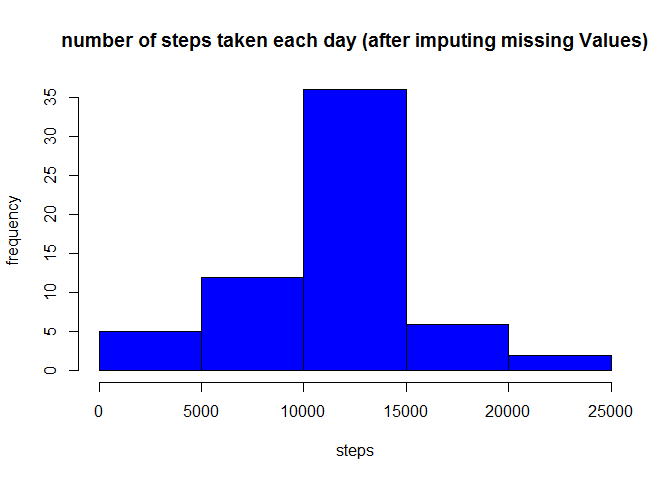

```r
ac6 <- aggregate(data.frame(tsteps =ac5$steps), by =list(day = ac5$date), sum)

hist(ac6$tsteps, main="number of steps taken each day (after imputing missing Values)",
     xlab="steps", ylab= "frequency", col="blue" )
```

5. Calculate and report the mean and median total number of steps taken per day.

```r
aggregate(data.frame(mnsteps =ac5$steps), by =list(day = ac5$date), mean)
```

```
##           day    mnsteps
## 1  2012-10-01 37.3825996
## 2  2012-10-02  0.4375000
## 3  2012-10-03 39.4166667
## 4  2012-10-04 42.0694444
## 5  2012-10-05 46.1597222
## 6  2012-10-06 53.5416667
## 7  2012-10-07 38.2465278
## 8  2012-10-08 37.3825996
## 9  2012-10-09 44.4826389
## 10 2012-10-10 34.3750000
## 11 2012-10-11 35.7777778
## 12 2012-10-12 60.3541667
## 13 2012-10-13 43.1458333
## 14 2012-10-14 52.4236111
```

[output cut: 47 more lines]

```r
aggregate(data.frame(mdsteps =ac5$steps), by =list(day = ac5$date), median)
```

```
##           day  mdsteps
## 1  2012-10-01 34.11321
## 2  2012-10-02  0.00000
## 3  2012-10-03  0.00000
## 4  2012-10-04  0.00000
## 5  2012-10-05  0.00000
## 6  2012-10-06  0.00000
## 7  2012-10-07  0.00000
## 8  2012-10-08 34.11321
## 9  2012-10-09  0.00000
## 10 2012-10-10  0.00000
## 11 2012-10-11  0.00000
## 12 2012-10-12  0.00000
## 13 2012-10-13  0.00000
## 14 2012-10-14  0.00000
```

[output cut: 47 more lines]

Do these values differ from the estimates from the first part of the assignment? What is the impact of imputing missing data on the estimates of the total daily number of steps?

- Answer 1: mean and median values have changed with the imputing of missing data.
- Answer 2: imputing missing data has increased the total of daily steps.

## Are there differences in activity patterns between weekdays and weekends?

1. Create a new factor variable in the dataset with two levels - “weekday” and “weekend” indicating whether a given date is a weekday or weekend day.

```r
library(dplyr)
ac7 <- mutate(ac5,dt = ifelse(weekdays(as.Date(date)) %in% c("Sunday","Saturday"),"weekend" , "weekday" ))
ac8 <- select(ac7, steps,interval,dt)
ac9 <- group_by(ac8,dt,interval)
ac10 <- summarise(ac9,asteps=mean(steps))
```

2. Make a panel plot containing a time series plot (i.e. type = “l”) of the 5-minute interval (x-axis) and the average number of steps taken, averaged across all weekday days or weekend days (y-axis)

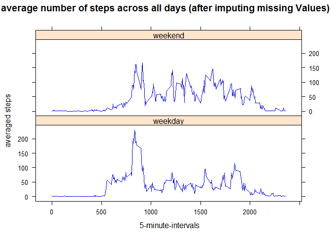

```r
library(lattice)
xyplot(asteps ~ interval|dt, data = ac10, layout=c(1,2),type="l",col="blue",main="average number of steps across all days (after imputing missing Values)", xlab=" 5-minute-intervals", ylab="averaged steps")
```